# Crypto Cointegration

Manuel Hanuch

```r
library(tseries)
library(urca)
```

Welcome to My ORIE 5640 final Project. In this notebook, I will be exploring time series of crypto assets to see if there are any cointegrated time series. I was able to find standardized daily level data for a variety of different cryptocurrencies from Kaggle, and wrote a script in Python (get_data.py)to select and combine the different assets into one csv file so that the dates align. We will be trying to find several different relationships, so this script will come in handy.

Lets start off with some EDA.

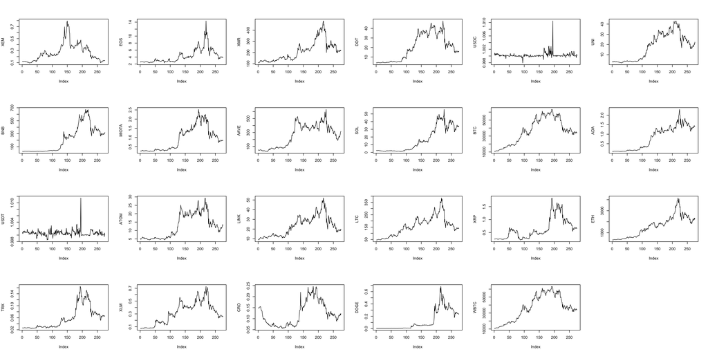

```r
allcoins = read.csv('allcoins.csv')


par(mfrow=c(4,6))

for(i in colnames(allcoins)[-1]){
  plot(allcoins[[i]],type = 'l',ylab = i)

}
```

So here are all the time series. I notice that BTC ands WBTC are extremely similar. The reason for that, in short, is because WBTC is “an ERC-20 token that represents Bitcoin (BTC) on the Ethereum blockchain. A key advantage of WBTC is its integration into the world of Ethereum wallets, dapps, and smart contracts.” With that in mind,WBTC is meant to have the exact same value as BTC. However, due to market forces, their value is not always exactly the same. I suspect that the prices may be cointegrated. lets explore this further. Perhaps there is potential for a trading strategy!

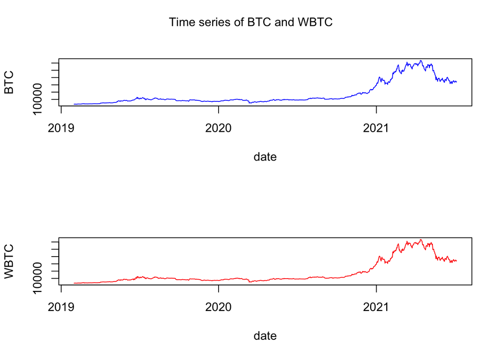

```r
btc.wbtc = read.csv('btc_wbtc.csv')

date = btc.wbtc[['Date']]
date = as.Date(date) #set date to date object

par(mfrow=c(2,1))

plot(date,btc.wbtc$BTC,type = 'l',col='blue',ylab='BTC')
plot(date,btc.wbtc$WBTC,type = 'l',col = 'red',ylab='WBTC')

mtext("Time series of BTC and WBTC",                   # Add main title
      side = 3,
      line = - 2,
      outer = TRUE)
```

Above is a clearer picture of how similar the time series are. First, lets regress WBTC prices on BTC since BTC is the original.

```r
btc.wbtc.lm = lm(WBTC ~ BTC, data = btc.wbtc )
print(btc.wbtc.lm$coefficients)
```

```
## (Intercept)         BTC
##   4.4967399   0.9997674
```

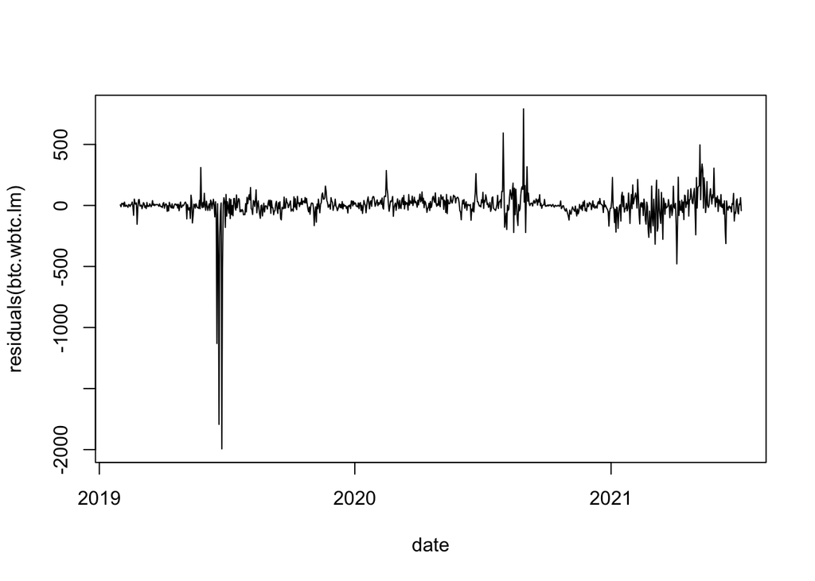

```r
plot(date,residuals(btc.wbtc.lm),type='l')
```

Aside from the large deviation, it looks like this could be stationary.

Below, lets use the phillips-Ouliaris test as a first pass.

```r
btc.wbtc= btc.wbtc[c('BTC','WBTC')]

ca.po(btc.wbtc)
```

```
##
## ########################################################
## # Phillips and Ouliaris Unit Root / Cointegration Test #
## ########################################################
##
## The value of the test statistic is: 1188.524
```

the large test statistic leads us to reject the null of no cointegration, and may suggest evidence that these prices are cointegrated.

Next lets check vecm using johansen procedure

```r
options(digits=3,width=60)
btc.wbtc.cajo = ca.jo(btc.wbtc)
summary(btc.wbtc.cajo)
```

```
##
## ######################
## # Johansen-Procedure #
## ######################
##
## Test type: maximal eigenvalue statistic (lambda max) , with linear trend
##
## Eigenvalues (lambda):
## [1] 0.258587 0.000634
##
## Values of teststatistic and critical values of test:
##
##            test 10pct  5pct 1pct
## r <= 1 |   0.56   6.5  8.18 11.7
## r = 0  | 265.09  12.9 14.90 19.2
##
## Eigenvectors, normalised to first column:
## (These are the cointegration relations)
##
##         BTC.l2 WBTC.l2
## BTC.l2       1    1.00
## WBTC.l2     -1    0.25
##
## Weights W:
## (This is the loading matrix)
##
##        BTC.l2  WBTC.l2
## BTC.d   0.256 -0.00129
## WBTC.d  0.984 -0.00127
```

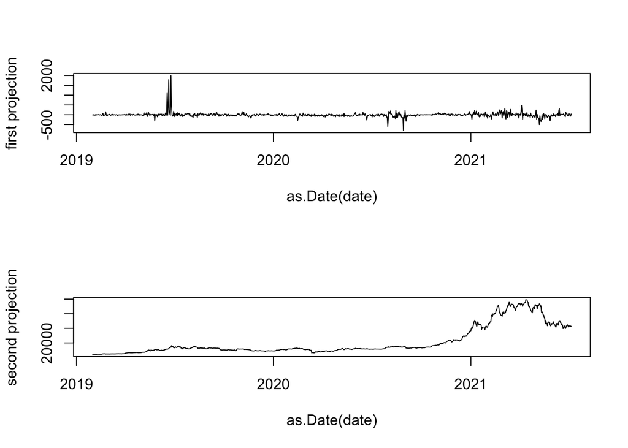

```r
par(mfrow=c(2,1))
plot(as.Date(date),as.matrix(btc.wbtc)%*% btc.wbtc.cajo@V[,1],type="l",ylab="first projection")
plot(as.Date(date),as.matrix(btc.wbtc)%*%btc.wbtc.cajo@V[,2],type="l",ylab="second projection")
```

First one looks stationary. Lets test using adf and kpss.

```r
adf.test(as.matrix(btc.wbtc)%*% btc.wbtc.cajo@V[,1])
```

```
##
##  Augmented Dickey-Fuller Test
##
## data:  as.matrix(btc.wbtc) %*% btc.wbtc.cajo@V[, 1]
## Dickey-Fuller = -7, Lag order = 9, p-value = 0.01
## alternative hypothesis: stationary
```

```r
kpss.test(as.matrix(btc.wbtc)%*% btc.wbtc.cajo@V[,1])
```

```
##
##  KPSS Test for Level Stationarity
##
## data:  as.matrix(btc.wbtc) %*% btc.wbtc.cajo@V[, 1]
## KPSS Level = 0.4, Truncation lag parameter = 6,
## p-value = 0.06
```

The adf and kpss tests agree with each other!

Lets Quickly redo this using log prices:

```r
#take the log of the time series
l.btc.wbtc = log(btc.wbtc)

#regress log prices on one another and plot residuals
l.btc.wbtc.lm = lm(WBTC ~ BTC, data = l.btc.wbtc )
print(l.btc.wbtc.lm$coefficients)
```

```
## (Intercept)         BTC
##     0.00604     0.99939
```

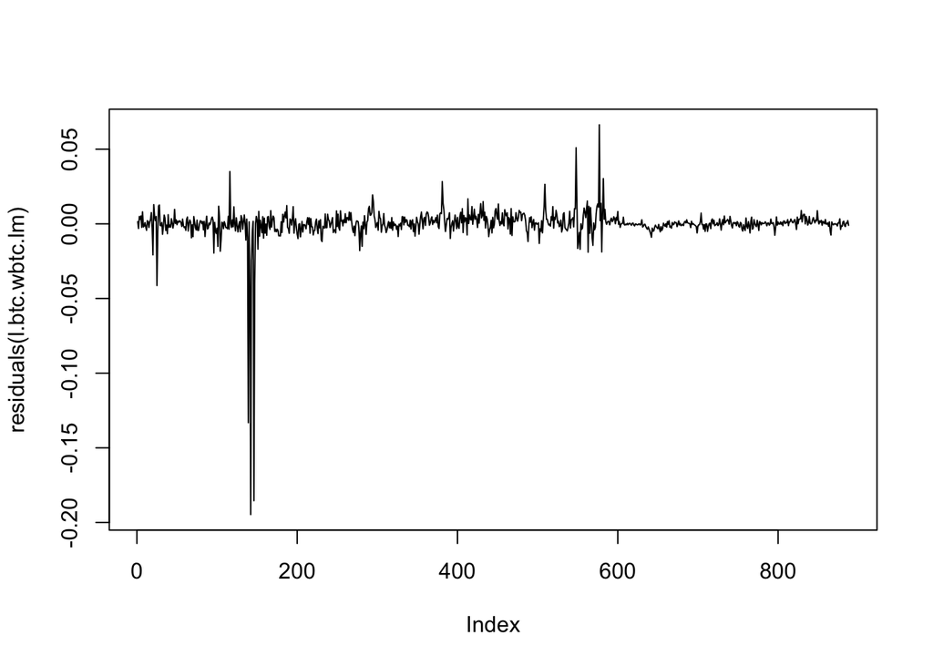

```r
plot(residuals(l.btc.wbtc.lm),type='l')
```

```r
#po test on log prices
ca.po(l.btc.wbtc)
```

```
##
## ########################################################
## # Phillips and Ouliaris Unit Root / Cointegration Test #
## ########################################################
##
## The value of the test statistic is: 1173
```

```r
#verc on log prices
options(digits=3,width=60)
l.btc.wbtc.cajo = ca.jo(l.btc.wbtc)
summary(l.btc.wbtc.cajo)
```

```
##
## ######################
## # Johansen-Procedure #
## ######################
##
## Test type: maximal eigenvalue statistic (lambda max) , with linear trend
##
## Eigenvalues (lambda):
## [1] 0.26208 0.00131
##
## Values of teststatistic and critical values of test:
##
##            test 10pct  5pct 1pct
## r <= 1 |   1.16   6.5  8.18 11.7
## r = 0  | 269.27  12.9 14.90 19.2
##
## Eigenvectors, normalised to first column:
## (These are the cointegration relations)
##
##         BTC.l2 WBTC.l2
## BTC.l2       1  1.0000
## WBTC.l2     -1  0.0813
##
## Weights W:
## (This is the loading matrix)
##
##        BTC.l2  WBTC.l2
## BTC.d   0.117 -0.00179
## WBTC.d  0.860 -0.00174
```

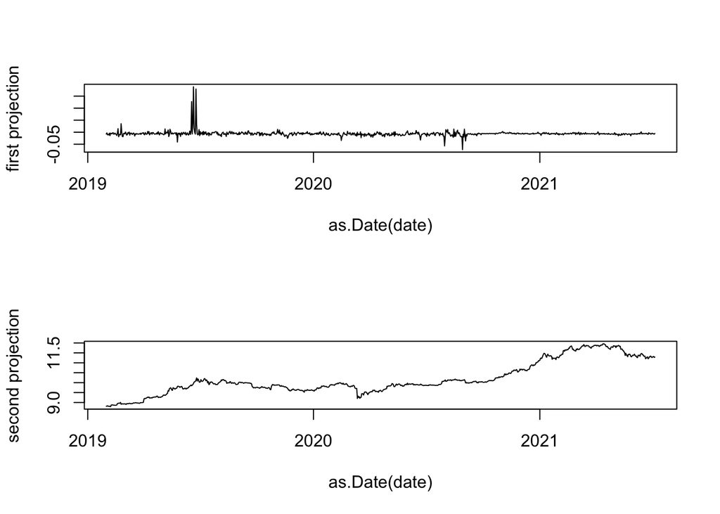

```r
#plot vecm
par(mfrow=c(2,1))
plot(as.Date(date),as.matrix(l.btc.wbtc)%*% l.btc.wbtc.cajo@V[,1],type="l",ylab="first projection")
plot(as.Date(date),as.matrix(l.btc.wbtc)%*% l.btc.wbtc.cajo@V[,2],type="l",ylab="second projection")
```

```r
#run stationarity tests on series with cointegrated vector
adf.test(as.matrix(l.btc.wbtc)%*% l.btc.wbtc.cajo@V[,1])
```

```
##
##  Augmented Dickey-Fuller Test
##
## data:  as.matrix(l.btc.wbtc) %*% l.btc.wbtc.cajo@V[, 1]
## Dickey-Fuller = -8, Lag order = 9, p-value = 0.01
## alternative hypothesis: stationary
```

```r
kpss.test(as.matrix(l.btc.wbtc)%*% l.btc.wbtc.cajo@V[,1])
```

```
##
##  KPSS Test for Level Stationarity
##
## data:  as.matrix(l.btc.wbtc) %*% l.btc.wbtc.cajo@V[, 1]
## KPSS Level = 0.6, Truncation lag parameter = 6,
## p-value = 0.02
```

Alright so we have the log prices and a cointegration vector of just simply (1,-1). The key theoretical result described in the paper depends on some lookback period, which is chosen through backtesting. I choose to test periods of one day to 100 trading days. According to the paper, the lookback period should be infinitely large, but we only have about 900 data points, so more than 100 might not really be smart.

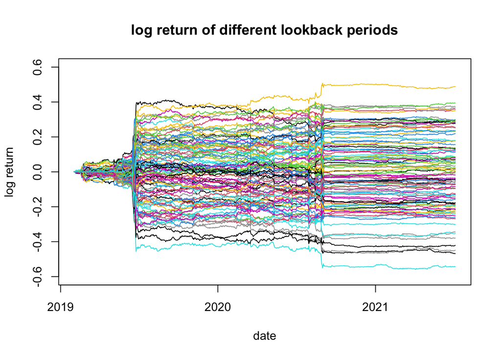

```r
#get cointegration vecgor
btilde = t(as.matrix(l.btc.wbtc.cajo@V[,1]))

#cointegrating vector says bitcoin is in the long and wbtc is short

#get the cointegrated process
Z = as.matrix(btilde) %*% t(diff(as.matrix(l.btc.wbtc)))

maxp = 100 #largest lookback period
C=1 #constant equal to one for now

#initialize matrix of returns for each lookback period
rets_for_different_p =  matrix(0, nrow = maxp, ncol = length(Z))


#loop through different p to see which p has the greatest return

for(p in 1:maxp){
  rets = matrix(0, nrow = dim(btilde)[2], ncol = length(Z))
  for( i in p:length(Z-1)){

    shares_btc = -C*sign(sum(Z[i-p:i]))
    shares_wbtc = C*sign(sum(Z[i-p:i]))

    #get the next period log return of our position for each asset
    rets[1,i] = shares_btc * diff(l.btc.wbtc$BTC)[i+1]
    rets[2,i] = shares_wbtc * diff(l.btc.wbtc$WBTC)[i+1]
  }

  #to get the portfoilo return, we can just average the two returns
  port_ret = colMeans(rets)

  #add portfolio return for each p to the matrix.
  rets_for_different_p[p,] = port_ret

}

#plot the return o each strategy
for( i in 1:dim(rets_for_different_p)[1]){
  if(i==1){
      plot(date[-1],cumsum(rets_for_different_p[i,]),
           type='l',
           ylim = c(-.6,.6),
           col=i,
           ylab = 'log return',
           xlab='date',
           main = 'log return of different lookback periods')
  }
  else{
    lines(x=date[-1], y = cumsum(rets_for_different_p[i,]),col=i+1)
  }
}
```

Now which one has the best (annualized) sharpe ratio? lets assume for now that the risk free rate is 0.

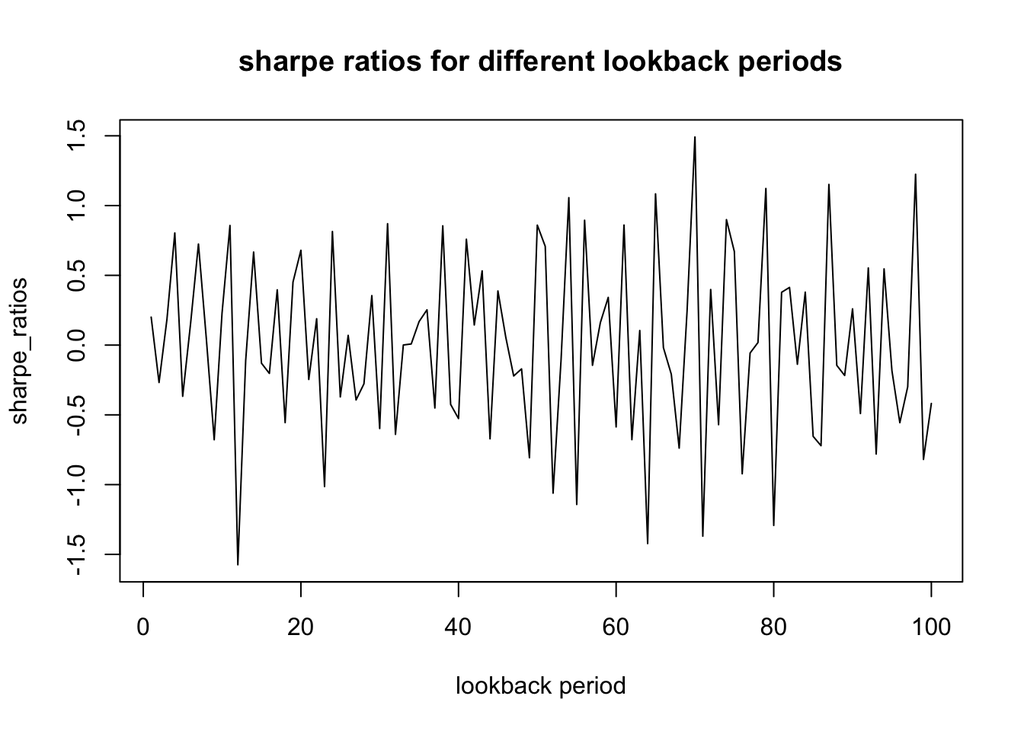

```r
#first lets set all values that are 0 to na so they get ignored in the following calculations. the 0's will throw off sd calculations.

rets_for_different_p[rets_for_different_p==0] = NA

standard_devs = apply(rets_for_different_p,1,sd,na.rm=TRUE)
total_returns = apply(rets_for_different_p,1,mean,na.rm=TRUE)


sharpe_ratios = sqrt(365)*(total_returns/standard_devs) #365 since they trade every day

plot(sharpe_ratios,type='l', main = 'sharpe ratios for different lookback periods',xlab='lookback period')
```

Those are the sharpe ratios.

```r
print(sharpe_ratios[which.max(sharpe_ratios)])
```

```
## [1] 1.49
```

```r
print(which.max(sharpe_ratios))
```

```
## [1] 70
```

The best sharpe ratio is 1.49 for a lookback period of 70 days. This isn’t a horrible sharpe ratio, but it isn’t a great one either.

Our data is only from January 31st 2019 - July 7th 2021. Luckily, there is more data available on Yahoo finance for July 8 2021 to today, May 16th 2022. Lets test the strategy. lets get 70days prior to that so that we can start the lookback period doesnt eat any of our data.

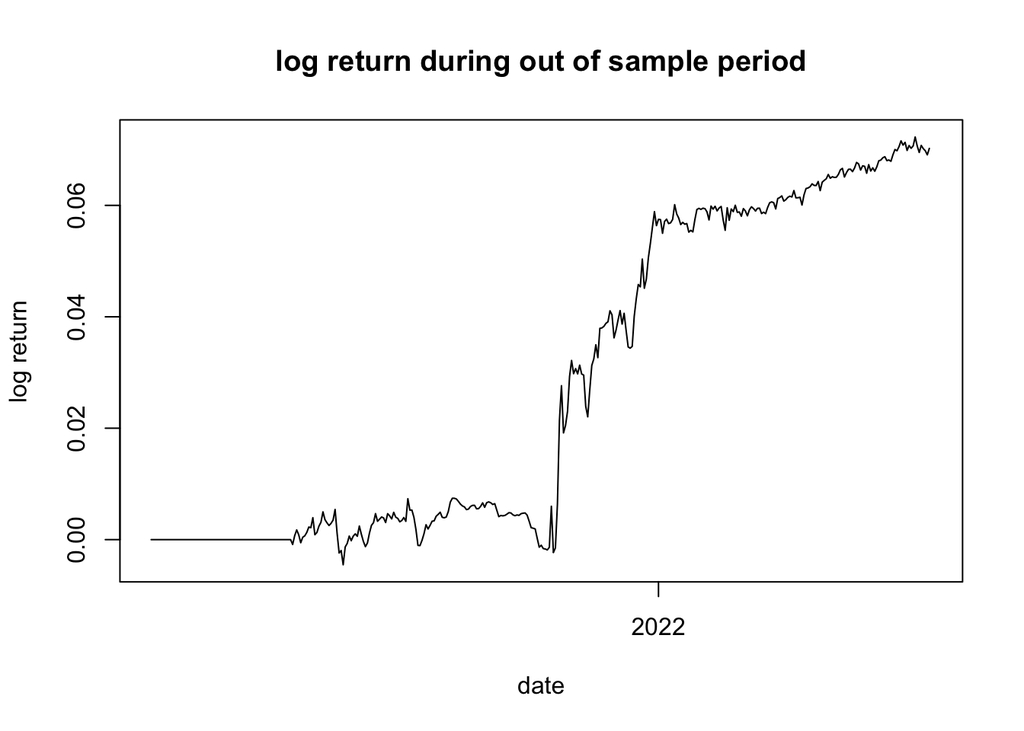

```r
#we have test data that starts one full lookback period (70 days) before any new data comes in because there will be no trades made before that
# and so our data doesnt get eaten.

#load data
btc_test = read.csv('BTC-USD_recent.csv')
wbtc_test = read.csv('WBTC-USD_recent.csv')

#get dates
newdates = as.Date(btc_test$Date,format = "%m/%d/%Y")

#bind columns
test = cbind(btc_test$Close,wbtc_test$Close)
colnames(test) = c('BTC','WBTC')

#get log prices
log_test = as.data.frame(log(test))

#get the cointegrated pricess
Z_test = as.matrix(btilde) %*% t(diff(as.matrix(log_test)))



#get optimal lookback
p_opt = which.max(sharpe_ratios)
#set up empty matrix
testrets = matrix(0, nrow = dim(btilde)[2], ncol = length(Z_test))

for( i in p_opt:length(Z_test-1)){

  shares_btc = -C*sign(sum(Z_test[i-p_opt:i]))
  shares_wbtc = C*sign(sum(Z_test[i-p_opt:i]))

  #get the next period log return of our position for each asset

  testrets[1,i] = shares_btc * diff(log_test$BTC)[i+1]
  testrets[2,i] = shares_wbtc * diff(log_test$WBTC)[i+1]
}

#to get the portfoilo return, we can just average the two returns
test_port_ret = colMeans(testrets)

plot(newdates[-1],cumsum(test_port_ret),type='l',
     main='log return during out of sample period',
     ylab = 'log return',
     xlab = 'date')
```

Decent performance. log Return of .07.

```r
test_port_ret[test_port_ret==0] = NA

test_sharpe_ratio = sqrt(365)*(mean(test_port_ret,na.rm=TRUE)/sd(test_port_ret,na.rm = TRUE)) #365 trading days

test_sharpe_ratio
```

```
## [1] 2.16
```

Not bad!